# Análisis de Línea de producción de Pastas

Dra. Eva Marcela Licea De Anda

2024-06-20

Análisis de capacidad de producción del contenido en paquetes de pasta de la línea 1 de la empresa FIDEOS & PASTAS.

Se ha realizado un muestreo sistemático de 5 muestras cada hora, durante 24 horas. La información se encuentra en la siguiente base de datos

# Análisis de Contenido de Pastas

```r
linea1 <- read.table("linea1.csv", sep = ",", header = TRUE)
linea1
```

| x1 | x2 | x3 | x4 | x5 |
| --- | --- | --- | --- | --- |
| 194 | 195 | 198 | 196 | 205 |
| 197 | 193 | 200 | 205 | 191 |
| 204 | 205 | 203 | 209 | 200 |
| 201 | 195 | 195 | 190 | 205 |
| 188 | 189 | 194 | 193 | 187 |
| 190 | 202 | 193 | 207 | 201 |
| 192 | 206 | 188 | 185 | 210 |
| 195 | 191 | 196 | 194 | 195 |
| 168 | 194 | 195 | 201 | 214 |
| 200 | 204 | 202 | 204 | 208 |

[output cut: 14 more lines]

Creamos un vector con todos los datos de los subgrupos de la línea 1

```r
vlinea1 = c(linea1$x1, linea1$x2, linea1$x3, linea1$x4, linea1$x5)
```

## Estadísticos de Tendencia Central

```r
summary(vlinea1)
```

```
##    Min. 1st Qu.  Median    Mean 3rd Qu.    Max.
##   168.0   195.0   202.0   200.7   207.0   214.0
```

Guardamos en objetos los valores de los estadísticos

```r
library(modeest)
media_linea1 = mean(vlinea1)
media_linea1
```

```
## [1] 200.675
```

```r
mediana_linea1 = median(vlinea1)
mediana_linea1
```

```
## [1] 202
```

```r
moda_linea1 = mlv(vlinea1)
moda_linea1
```

```
## [1] 204
```

## Estadísticos de Dispersión

```r
desviacion_est_linea1 = sd(vlinea1)
desviacion_est_linea1
```

```
## [1] 8.160329
```

```r
varianza_linea1 = var(vlinea1)
varianza_linea1
```

```
## [1] 66.59097
```

```r
max_linea1 = max(vlinea1)
max_linea1
```

```
## [1] 214
```

```r
min_linea1 = min(vlinea1)
min_linea1
```

```
## [1] 168
```

```r
rango_linea1 = max_linea1 - min_linea1
rango_linea1
```

```
## [1] 46
```

## Histograma -Gráfica de Capacidad-

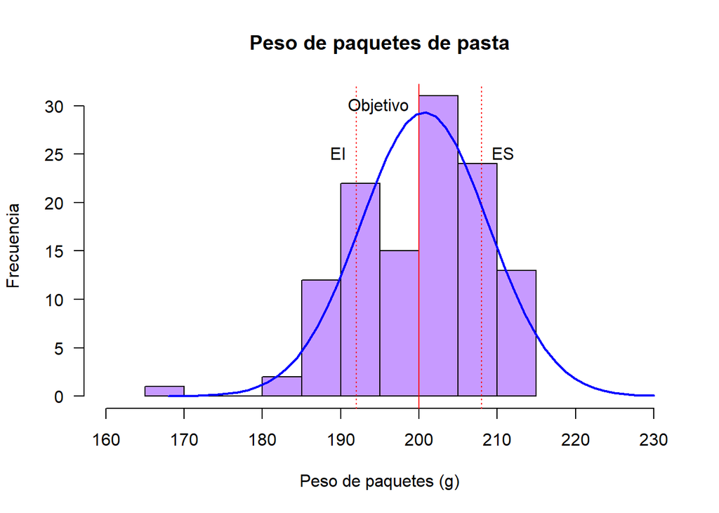

```r
ES <- 208
EI <- 192
N= 200
h = hist(vlinea1, breaks= "sturges", freq = TRUE, right = TRUE,
         col = "#C79AFF", border = "black",
         main = "Peso de paquetes de pasta",
         xlim = c (160,230), xlab = "Peso de paquetes (g)",
         ylab = "Frecuencia", las=1)
abline(v = ES, col = "red",lty=3)
text(EI, 25, "EI", cex= NULL, pos=2, col="black")
abline(v = EI, col = "red",lty=3)
text(ES, 25, "ES", cex= NULL, pos=4, col="black")
abline(v = N , col = "red",lty=1)
text(N, 30, "Objetivo", cex= NULL, pos=2, col="black")
myx = seq(min(vlinea1), 230, length.out= 50)
mymean = mean(vlinea1)
mysd = sd(vlinea1)
normal = dnorm(x = myx, mean = mymean, sd = mysd)
multiplier = h$counts / h$density
lines (myx, normal * multiplier[1], col = "blue", lwd = 2)
```

## Prueba de Hipótesis

```r
alpha= 0.05
mu0= 200
n_linea1= length(vlinea1)
n_linea1
```

```
## [1] 120
```

```r
zTest = (media_linea1 - mu0)/ (desviacion_est_linea1/sqrt(n_linea1))
zTest
```

```
## [1] 0.9061221
```

```r
zalphaiz <- qnorm(alpha/2,lower.tail = TRUE)
zalphaiz
```

```
## [1] -1.959964
```

```r
zalphader <- qnorm(alpha/2, lower.tail = FALSE)
zalphader
```

```
## [1] 1.959964
```

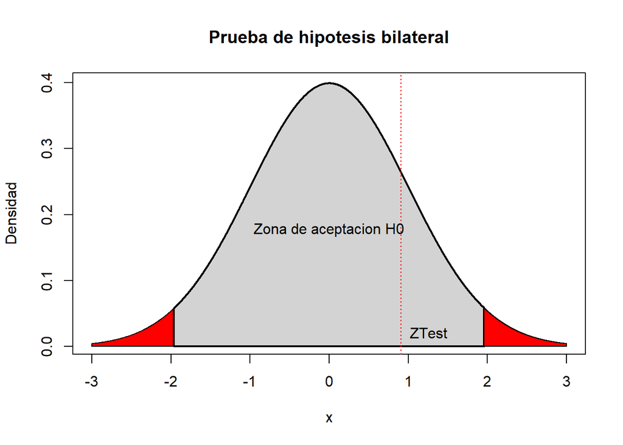

```r
x = pretty(-3:3,n = 50)
y = dnorm(x)
plot(x,y, ylab = "Densidad", type = "l", col = "black",
     main="Prueba de hipotesis bilateral")
xi <- c(-3,seq(-3,zalphaiz,by = 0.001),zalphaiz)
yi <- c(0,dnorm(seq(-3,zalphaiz,by = 0.001)),0)
polygon(xi,yi,col = "red",lty = 1,lwd=1)
cor.x = c(zalphaiz, seq(zalphaiz,zalphader, by=0.001),zalphader)
cor.y = c(0,dnorm(seq(zalphaiz, zalphader, by=0.001)),0)
polygon(cor.x,cor.y, col = "lightgrey",lty = 1,lwd=2)
xd = c(zalphader,seq(zalphader,3, by=0.001),3)
yd = c(0,dnorm(seq(zalphader,3,by=0.001)),0)
polygon(xd,yd, angle = 45,col = "red",lty = 1,lwd=1)
text(zTest, 0.02, "ZTest", cex= NULL, pos=4, col="black")
abline(v = zTest, col = "red",lty=3)
text(0, 0.2 , "Zona de aceptacion H0", cex= NULL, pos=1, col="black")
```

### Prueba de normalidad

Determinar si los datos siguien una distribución normal, hacer un gráfico q-q y aplicar el test de Shapiro. Shapiro.test se usa para contrastar si un conjunto de datos sigue una distribución normal o no H0: los datos provienen de una distribución normal, Ha: los datos no provienen de una distribución normal sí p-value ≤ 0.05 se rechaza la hipótesis nula si p-value ≥ 0.05 no se rechaza la hipótesis nula.

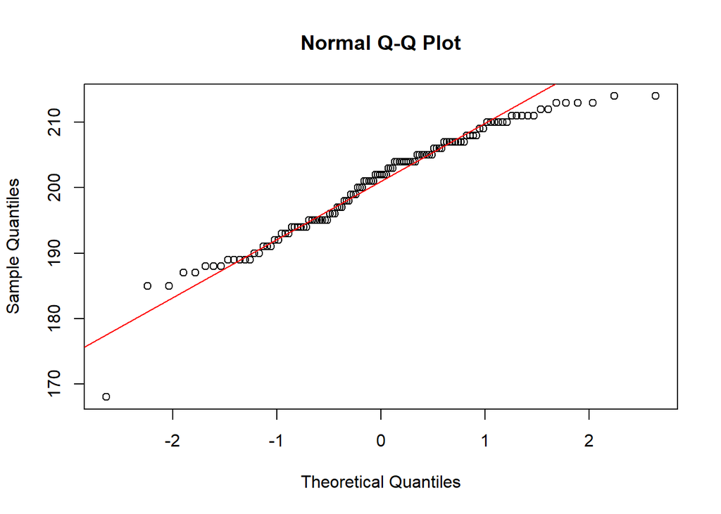

```r
qqnorm(vlinea1)
qqline (vlinea1, col = "red")
```

```r
shapiro.test(vlinea1)
```

```
##
##  Shapiro-Wilk normality test
##
## data:  vlinea1
## W = 0.9556, p-value = 0.0005704
```

### Estimación de μx y σx

Debido a que los datos obtenidos, no son a largo plazo, se deberá estimar la media y desviación a largo plazo, empleando los subgrupos, n=5 por lo que 𝑑2=2.326 (Revisar apéndice)

```r
row.sums <- apply(linea1, 1, mean)
mini <- apply(linea1, 1 , min)
maxi <- apply(linea1, 1 , max)
mu <- mean(row.sums)
mu
```

```
## [1] 200.675
```

```r
rango = maxi - mini
d2 = 2.326
rdesvest = mean(rango)/d2
rdesvest
```

```
## [1] 7.039983
```

## Indices de Capacidad

```r
Cp = (ES-EI)/(6*rdesvest)
Cp
```

```
## [1] 0.3787888
```

```r
Cr = (6*rdesvest)/(ES-EI)
Cr
```

```
## [1] 2.639994
```

```r
Cpi = (mu-EI)/(3*rdesvest)
Cpi
```

```
## [1] 0.4107491
```

```r
Cps = (ES-mu)/(3*rdesvest)
Cps
```

```
## [1] 0.3468285
```

```r
Cpk = min(Cpi,Cps)
Cpk
```

```
## [1] 0.3468285
```

```r
tau = sqrt((rdesvest^2)+((mu-N)^2))
Cpm = (ES-EI)/(6*tau)
Cpm
```

```
## [1] 0.3770596
```

```r
zi = 3*Cpi
Pzi = 1-pnorm(zi)
PPMFEi = Pzi*1000000
PPMFEi
```

```
## [1] 108928.4
```

Partes por millón fuera de especificación con mayor cantidad de pasta

```r
zs = 3*Cps
Pzs = 1-pnorm(zs)
PPMFEs = Pzs*1000000
PPMFEs
```

```
## [1] 149057.2
```

Partes por millón fuera de especificación

```r
zbench = qnorm(1-(Pzi+Pzs))
Pzbench = 1-pnorm(zbench)
PPMFE = Pzbench*1000000
PPMFE
```

```
## [1] 257985.6
```

### Resumen de todos los índices de capacidad

```r
Resumen_indices_linea1 = data.frame(Cp,Cpi,Cps,Cpk,zi,Pzi,PPMFEi,zs,Pzs,PPMFEs,zbench,Pzbench,PPMFE,Cpm)
Resumen_indices_linea1
```

| Cp | Cpi | Cps | Cpk | zi | Pzi | PPMFEi | zs | Pzs | PPMFEs | zbench | Pzbench | PPMFE | Cpm |
| --- | --- | --- | --- | --- | --- | --- | --- | --- | --- | --- | --- | --- | --- |
| 0.3787888 | 0.4107491 | 0.3468285 | 0.3468285 | 1.232247 | 0.1089284 | 108928.4 | 1.040485 | 0.1490572 | 149057.2 | 0.6495683 | 0.2579856 | 257985.6 | 0.3770596 |

# Analisis de capacidad con la librería SixSigma

```r
library(SixSigma)
```

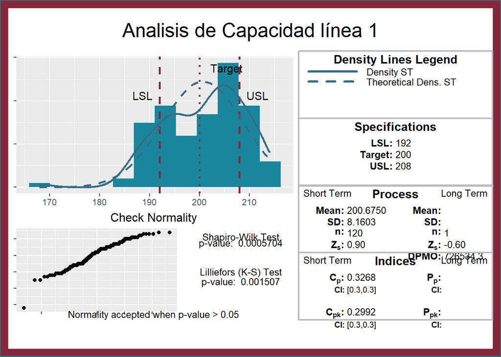

```r
ss.study.ca(vlinea1, LSL= 192, USL= 208,
            Target = 200, alpha=0.5,
            f.main= "Analisis de Capacidad línea 1",
            f.colours= c("#1b859d", "#356e84", "#50576b", "#6a3f52", "#842839"),"midnightblue")
```

# Bibliografía

Fuente original: http://www.ptolomeo.unam.mx:8080/xmlui/bitstream/handle/132.248.52.100/16773/Tesis.pdf?sequence=3&isAllowed=y Adaptado para el estudio de Control Estadístico de Procesos. Mejía Cervantes Karen Evelyn. Análisis de Control Estadístico de calidad utilizando R R Markdown: The Definitive guide. Yihui Xie, J. J. Allaire, Garrett Grolemund https://bookdown.org/yihui/rmarkdown/